# Health Expenditures in the United States

## Health Expenditure by Sex and Age Group

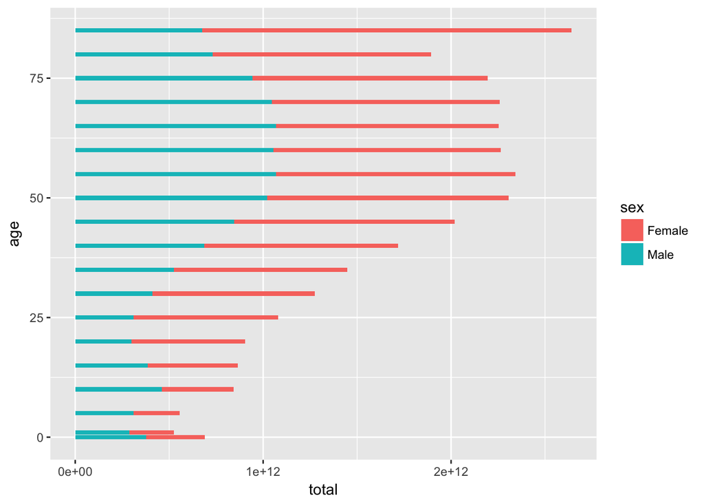

Above is a stacked bar chart comparing the total health expenditures of men and women across the various age groups of the study. Overall, health expenditures increase as the cohort ages, and more tends to be spent on women as they age. This may be because women have a higher life expectancy, and there will therefore be more of them incurring healthcare costs compared to men later in life. Because health expenditures are so big towards the end of ones life, I looked in to the main causes of expenditure, and compared them across sex to see what some of the most costly issues are.

### Top Health Expenses for Elderly Men

| Cause | total.cost |
| --- | --- |
| Ischemic heart disease | 613294752 |
| Cerebrovascular disease | 586878914 |
| Alzheimer’s disease and other dementias | 525269880 |
| Falls | 459364810 |
| Heart Failure | 455155200 |

### Top Health Expenses for Elderly Women

| Cause | total.cost |
| --- | --- |
| Alzheimer’s disease and other dementias | 3064708746 |
| Falls | 1822305661 |
| Ischemic heart disease | 1523785807 |
| Cerebrovascular disease | 1463397020 |
| Treatment of hypertension | 1462695931 |

## Varience in Cancer Expenditures

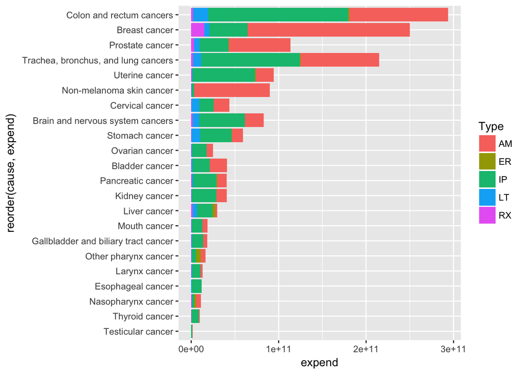